# SecA hydrogen deuterium exchange mass spectrometry data

Oliver M. Crook

16 February 2022

#### Abstract

This vignette describes how to analyse a mass-spectrometry based hydrogen deuterium exchange experiment, in particular we focus on empirical Bayes functional models and visualisations. This vignette descibes a case-study for analysing secA protein

#### Package

hdxstats 1.0

# 1 Introduction

Ahdash et al. performed HDX-MS on the baceterial sec translocon, a multi-protein complex responsible for translocating diverse proteins across the plasma membrane. Here we analyse this experiment using our functional data analysis approaches

# 2 loading packges

# 3 Data

The data is stored as a .csv, we need to covert it to an object of class `QFeatures`. This is performed in a number of steps which we detail below. The data is contained within the package and so can be loaded by specificy the correct path.

```r
secApath <- system.file("extdata", "Project_2_SecA_Cluster_Data.csv",
                        package = "hdxstats")
```

We can now read in the .csv file and have a quick look at the .csv.

```r
secA <- read.csv(secApath)
head(secA) # have a look
```

```
##   Protein Start End Sequence Modification Fragment MaxUptake      MHP State
## 1  RANDOM     4   8    LGGTQ           NA       NA         4 475.2511  SecA
## 2  RANDOM     4   8    LGGTQ           NA       NA         4 475.2511  SecA
## 3  RANDOM     4   8    LGGTQ           NA       NA         4 475.2511  SecA
## 4  RANDOM     4   8    LGGTQ           NA       NA         4 475.2511  SecA
## 5  RANDOM     4   8    LGGTQ           NA       NA         4 475.2511  SecA
## 6  RANDOM     4   8    LGGTQ           NA       NA         4 475.2511  SecA
##   Exposure                File z       RT  Inten   Center
## 1     0.00   291018_SecA_REF_5 1 3.693435 710541 475.5310
## 2     0.00   291018_SecA_REF_4 1 4.077553  13038 476.8321
## 3     0.00   291018_SecA_REF_3 1 3.719365 819312 475.4421
## 4     0.00   291018_SecA_REF_2 1 3.712732 559986 475.4829
## 5     0.00   291018_SecA_REF_1 1 3.677982 527423 475.5147
## 6     0.25 011118_SecA_15sec_1 1 3.724814 506213 475.9036
```

```r
length(unique(secA$Sequence)) # peptide sequences
```

```
## [1] 397
```

```r
unique(secA$State) # States
```

```
## [1] "SecA"           "SecAYEG"        "SecAYEG_ADP"    "SecAYEG_AMPPNP"
## [5] "SecA_ADP"       "SecA_AMPPNP"
```

Let us have a quick visualisation of some the data so that we can see some of the features

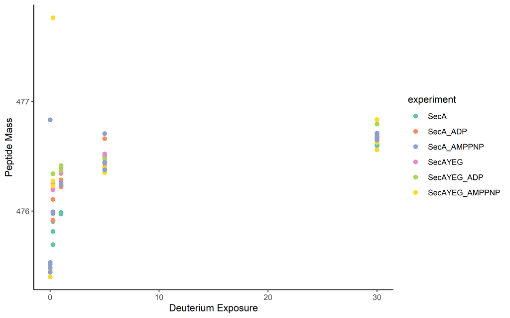

```r
filter(secA, Sequence == unique(secA$Sequence[1]), z == 1) %>%
    ggplot(aes(x = Exposure, y = Center, color = factor(State))) +
    theme_classic() + geom_point(size = 2) +
    scale_color_manual(values = brewer.pal(n = 7, name = "Set2")) +
    labs(color = "experiment", x = "Deuterium Exposure", y = "Peptide Mass")
```

# Parsing to an object of class QFeatures

Working from a .csv is likely to cause issues downstream. Indeed, we run the risk of accidently changing the data or corrupting the file in some way. Secondly, all .csvs will be formatted slightly different and so making extensible tools for these files will be inefficient. Furthermore, working with a generic class used in other mass-spectrometry fields can speed up analysis and adoption of new methods. We will work the class `QFeatures` from the `QFeatures` class as it is a powerful and scalable way to store quantitative mass-spectrometry data.

Firstly, the data is storted in long format rather than wide format. We first switch the data to wide format.

```r
secA <- pivot_wider(data.frame(secA),
                        values_from = "Center",
                        names_from = c("Exposure", "File", "State"),
                        id_cols = c("Sequence", "z"))
head(secA)
```

```
## # A tibble: 6 x 107
##   Sequence     z `0_291018_SecA_REF_5_SecA` `0_291018_SecA_RE~ `0_291018_SecA_R~
##   <chr>    <int>                      <dbl>              <dbl>             <dbl>
## 1 LGGTQ        1                       476.               477.              475.
## 2 MLIKL        1                       618.               618.              618.
## 3 LIKLLT       1                       701.               701.              701.
## 4 IKLLT        1                       588.               588.              588.
## 5 IINAME       1                       691.               691.              691.
## 6 AMEPEM       1                       708.               708.              708.
## # ... with 102 more variables: 0_291018_SecA_REF_2_SecA <dbl>,
## #   0_291018_SecA_REF_1_SecA <dbl>, 0.25_011118_SecA_15sec_1_SecA <dbl>,
## #   0.25_011118_SecA_15sec_2_SecA <dbl>, 0.25_011118_SecA_15sec_3_SecA <dbl>,
## #   1_011118_SecA_1min_1_SecA <dbl>, 1_011118_SecA_1min_2_SecA <dbl>,
## #   1_011118_SecA_1min_3_SecA <dbl>, 5_011118_SecA_5min_1_SecA <dbl>,
## #   5_011118_SecA_5min_2_SecA <dbl>, 5_011118_SecA_5min_3_SecA <dbl>,
## #   30.000002_011118_SecA_30min_1_SecA <dbl>, ...
```

We notice that there are many columns with `NA`s. The follow code chunk removes these columns.

```r
secA <- secA[, colSums(is.na(secA)) != nrow(secA)]
```

We also note that the colnames are not very informative. We are going to format in a very specific way so that later functions can automatically infer the design from the column names. We provide in the format X(time)rep(replicate)cond(condition)

```r
colnames(secA[-c(1,2)])
```

```
##   [1] "0_291018_SecA_REF_5_SecA"
##   [2] "0_291018_SecA_REF_4_SecA"
##   [3] "0_291018_SecA_REF_3_SecA"
##   [4] "0_291018_SecA_REF_2_SecA"
##   [5] "0_291018_SecA_REF_1_SecA"
##   [6] "0.25_011118_SecA_15sec_1_SecA"
##   [7] "0.25_011118_SecA_15sec_2_SecA"
##   [8] "0.25_011118_SecA_15sec_3_SecA"
##   [9] "1_011118_SecA_1min_1_SecA"
##  [10] "1_011118_SecA_1min_2_SecA"
##  [11] "1_011118_SecA_1min_3_SecA"
##  [12] "5_011118_SecA_5min_1_SecA"
##  [13] "5_011118_SecA_5min_2_SecA"
##  [14] "5_011118_SecA_5min_3_SecA"
##  [15] "30.000002_011118_SecA_30min_1_SecA"
```

[output cut: 90 more lines]

```r
new.colnames <- gsub("0_", "0rep", paste0("X", colnames(secA)[-c(1,2)]))
new.colnames <- gsub("X0.25_", "X15rep", new.colnames) # convert to seconds too
new.colnames <- gsub("X1_", "X60rep", new.colnames) # convert to seconds too
new.colnames <- gsub("X5_", "X300rep", new.colnames) # convert to seconds too
new.colnames <- gsub("X30.000002_", "X1800rep", new.colnames) # convert to seconds too
new.colnames <- gsub(new.colnames, pattern = "rep.*?SecA_", replacement = "rep")
new.colnames <- gsub(new.colnames, pattern = "rep.*?_[0-9]_", replacement = "repcond")
repnumber <- c(seq.int(5), rep(c(1,2,3), times = 19),
               seq.int(5), rep(c(1,2,3), times = 4),
               seq.int(5), rep(c(1,2,3), times = 4), rep(c(4,5,6), each = 3))
new.colnames <- stringr::str_replace_all(string = new.colnames,
                                pattern = "rep",
                                replacement = paste0("rep", repnumber))
new.colnames
```

```
##   [1] "X0rep1condSecA"              "X0rep2condSecA"
##   [3] "X0rep3condSecA"              "X0rep4condSecA"
##   [5] "X0rep5condSecA"              "X15rep1condSecA"
##   [7] "X15rep2condSecA"             "X15rep3condSecA"
##   [9] "X60rep1condSecA"             "X60rep2condSecA"
##  [11] "X60rep3condSecA"             "X300rep1condSecA"
##  [13] "X300rep2condSecA"            "X300rep3condSecA"
##  [15] "X1800rep1condSecA"           "X1800rep2condSecA"
##  [17] "X1800rep3condSecA"           "X0rep1condSecAYEG"
##  [19] "X0rep2condSecAYEG"           "X0rep3condSecAYEG"
##  [21] "X15rep1condSecAYEG"          "X15rep2condSecAYEG"
##  [23] "X15rep3condSecAYEG"          "X60rep1condSecAYEG"
##  [25] "X60rep2condSecAYEG"          "X60rep3condSecAYEG"
##  [27] "X300rep1condSecAYEG"         "X300rep2condSecAYEG"
##  [29] "X300rep3condSecAYEG"         "X1800rep1condSecAYEG"
```

[output cut: 38 more lines]

We will now parse the data into an object of class `QFeatures`, we have provided a function to assist with this in the package. If you want to do this yourself use the `readQFeatures` function from the `QFeatures` package.

```r
secAqDF <- parseDeutData(object = DataFrame(secA),
                        design = new.colnames,
                        quantcol = 3:105, sequence = "Sequence", charge = "z")
```

# 4 normalisation

We normalise the data to uptake values based on the “undeuterated” mass of the peptide

```r
secA_newdf <- DataFrame(data.frame(assay(secAqDF) - apply(assay(secAqDF), 1, function(x) min(x, na.rm = TRUE))))
secA_newdf <- cbind(DataFrame(secA)[,1:2], secA_newdf)

secAqDF_norm <- parseDeutData(secA_newdf, design = new.colnames, quantcol = 3:105, sequence = "Sequence", charge = "z")
```

Normalised by exchange amides

```r
secAqDF_norm1 <- normalisehdx(secAqDF_norm,
                             sequence = unique(secA$Sequence),
                             method = "pc")
```

# 5 Heatmap visualisations of HDX data

To help us get used to the `QFeatures` we show how to generate a heatmap of these data from this object:

```r
pheatmap(t(assay(secAqDF_norm1)),
         cluster_rows = FALSE,
         cluster_cols = FALSE,
         color = brewer.pal(n = 9, name = "BuPu"),
         main = "secA heatmap",
         fontsize = 14,
         legend_breaks = c(0, 1, 2, 3, 4, 5, 6, max(assay(secAqDF))),
         legend_labels = c("0", "1", "2", "3", "4", "5", "6", "Incorporation"))
```

[figure not shown]

# Analysis

To simplify the analysis, we subset to examine the protein secA and seA bound to ADP.

```r
secAqDF_norm1_sub <- secAqDF_norm1[,c(1:17, 63:79)]
```

# 6 Functional data analysis of HDX-MS data

The `hdxstats` package uses an empirical Bayes functional approach to analyse the data. We explain this idea in steps so that we can get an idea of the approach. First we fit the parametric model to the data. This will allow us to explore the `HdxStatModel` class.

```r
res <- differentialUptakeKinetics(object = secAqDF_norm1_sub, #provide a QFeature object
                                  feature = rownames(secAqDF_norm1_sub)[[1]][5], # which peptide to do we fit
                                  start = list(a = NULL, b = NULL,  d = NULL, p = 1)) # what are the starting parameter guesses
```

Here, we see the `HdxStatModel` class, and that a Functional Model was applied to the data and a total of 2 models were fitted.

```r
res
```

```
## Object of class "HdxStatModel"
## Method: Functional Model
## Fitted 2
```

The `nullmodel` and `alternative` slots of an instance of `HdxStatModel` provide the underlying fitted models. The `method` and `formula` slots provide vital information about what analysis was performed. The `vis` slot provides a `ggplot` object so that we can visualise the functional fits.

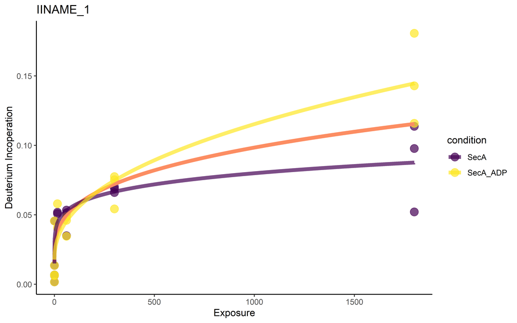

```r
res@vis
```

Since this is a ggplot object, we can customise in the usual grammatical ways.

```r
res@vis + scale_color_manual(values = brewer.pal(n = 8, name = "Set2")[-c(1,2)])
```

[output not shown]

[figure not shown]

# 7 Analysis of secA HDX-MS experiment

We have seen the basic aspects of our functional modelling approach. We now wish to roll out our method across all peptides in the experiment. The `fitUptakeKinetics` function allows us to apply our modelling approach across all the peptide in the experiment. We need to provide a `QFeatures` object and the features for which we are fitting the model. The design will be extracted from the column names or you can provide a design yourself. The parameter initilisation should also be provided. Sometimes the model can’t be fit on the kinetics. This is either because there is not enough data or through lack of convergence. An error will be reported in these cases but this should not perturb the user. You may wish to try a few starting values if there excessive models that fail fitting.

```r
res <- fitUptakeKinetics(object = secAqDF_norm1_sub,
                         feature = rownames(secAqDF_norm1_sub)[[1]],
                         start = list(a = NULL, b = NULL,  d = NULL, p = 1))
```

[output not shown]

[output not shown]

[output not shown]

[output not shown]

[output not shown]

[output not shown]

[output not shown]

[output not shown]

[output not shown]

[output not shown]

[output not shown]

[output not shown]

[output not shown]

[output not shown]

[output not shown]

[output not shown]

[output not shown]

[output not shown]

[output not shown]

[output not shown]

[output not shown]

[output not shown]

[output not shown]

[output not shown]

[output not shown]

[output not shown]

[output not shown]

[output not shown]

[output cut: 112 more lines]

[output not shown]

[output not shown]

[output not shown]

[output not shown]

[output not shown]

[output not shown]

[output not shown]

[output not shown]

[output not shown]

[output not shown]

[output not shown]

[output not shown]

[output not shown]

[output not shown]

[output not shown]

[output not shown]

[output not shown]

[output not shown]

[output not shown]

[output not shown]

[output not shown]

[output not shown]

[output not shown]

[output not shown]

[output not shown]

[output not shown]

[output not shown]

[output not shown]

[output not shown]

[output not shown]

[output not shown]

[output not shown]

[output not shown]

[output not shown]

[output not shown]

[output not shown]

[output not shown]

[output not shown]

[output not shown]

[output not shown]

[output not shown]

[output not shown]

[output not shown]

[output not shown]

[output not shown]

[output not shown]

[output not shown]

[output not shown]

[output not shown]

[output not shown]

[output not shown]

[output not shown]

[output not shown]

[output not shown]

[output not shown]

[output not shown]

[output not shown]

[output not shown]

[output not shown]

[output not shown]

[output not shown]

[output not shown]

[output not shown]

[output not shown]

[output not shown]

[output not shown]

[output not shown]

[output not shown]

[output not shown]

[output not shown]

[output not shown]

[output not shown]

[output not shown]

[output not shown]

[output not shown]

[output not shown]

[output not shown]

[output not shown]

[output not shown]

[output not shown]

[output not shown]

[output not shown]

[output not shown]

[output not shown]

[output not shown]

[output not shown]

[output not shown]

[output not shown]

[output not shown]

[output not shown]

[output not shown]

[output not shown]

[output not shown]

[output not shown]

[output not shown]

[output not shown]

[output not shown]

[output not shown]

[output not shown]

[output not shown]

[output not shown]

[output not shown]

[output not shown]

[output not shown]

[output not shown]

[output not shown]

[output not shown]

[output not shown]

[output not shown]

[output not shown]

[output not shown]

[output not shown]

[output not shown]

[output not shown]

[output not shown]

[output not shown]

[output not shown]

[output not shown]

[output not shown]

[output not shown]

[output not shown]

[output not shown]

[output not shown]

[output not shown]

[output not shown]

[output not shown]

[output not shown]

[output not shown]

[output not shown]

[output not shown]

[output not shown]

[output not shown]

[output not shown]

[output not shown]

[output not shown]

[output not shown]

[output not shown]

[output not shown]

[output not shown]

[output not shown]

[output not shown]

[output not shown]

[output not shown]

[output not shown]

[output not shown]

[output not shown]

[output not shown]

[output not shown]

[output not shown]

[output not shown]

[output not shown]

[output not shown]

[output not shown]

[output not shown]

[output not shown]

[output not shown]

[output not shown]

[output not shown]

[output not shown]

[output not shown]

[output not shown]

[output not shown]

[output not shown]

[output not shown]

[output not shown]

[output not shown]

[output not shown]

[output not shown]

[output not shown]

[output not shown]

[output not shown]

[output not shown]

[output not shown]

[output not shown]

[output not shown]

[output not shown]

[output not shown]

[output not shown]

[output not shown]

[output not shown]

[output not shown]

[output not shown]

[output not shown]

[output not shown]

[output not shown]

[output not shown]

[output not shown]

[output not shown]

[output not shown]

[output not shown]

[output not shown]

[output not shown]

[output not shown]

[output not shown]

[output not shown]

[output not shown]

[output not shown]

[output not shown]

[output not shown]

[output not shown]

[output not shown]

[output not shown]

[output not shown]

[output not shown]

[output not shown]

[output not shown]

[output not shown]

The code chunk above returns a class `HdxStatModels` indicating that a number of models for peptide have been fit. This is simply a holder for a list of `HdxStatModel` instances.

```r
res
```

```
## Object of class "HdxStatModels"
## Number of models 204
```

We can easily examine individual fits by going to the underyling `HdxStatModel` class:

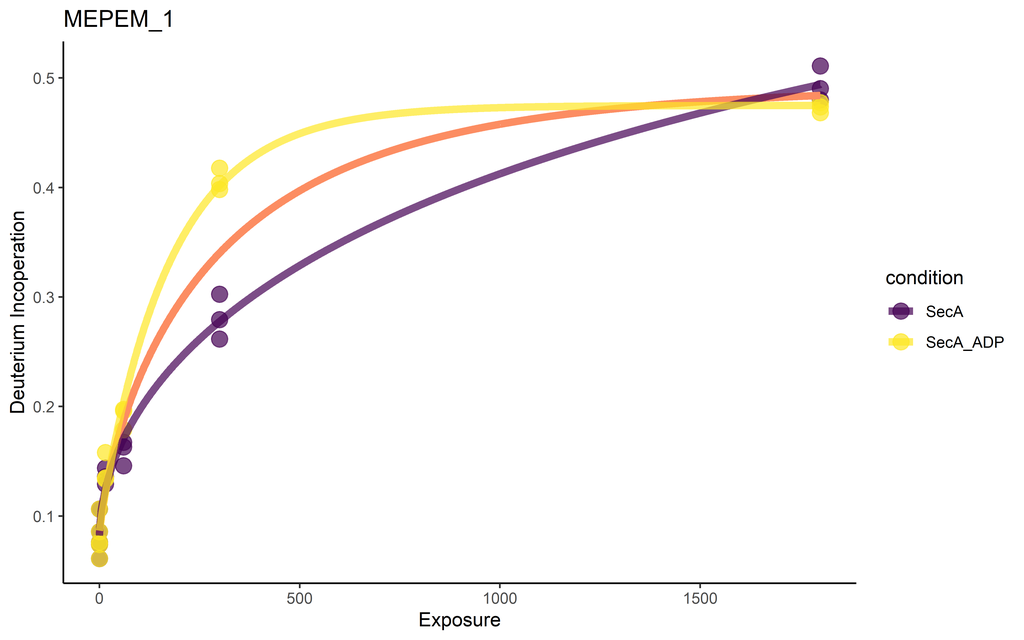

```r
res@statmodels[[4]]@vis
```

We now wish to apply statistical analysis to these fitted curves. Our approach is an empirical Bayes testing procedure, which borrows information across peptides to stablise variance estimates. Here, we need to provide the original data that was analysed and the `HdxStatModels` class. The following code chunk returns an object of class `HdxStatRes`. This object tell us that statistical analysis was performed using our Functional model.

```r
out <- processFunctional(object = secAqDF_norm1_sub, params = res)
out
```

```
## Object of class "HdxStatRes"
## Analysed using Functional model
```

The main slot of interest is the `results` slot which returns quantities of interest such as `p-values` and `fdr` corrected p-values because of multiple testing. The following is the `DataFrame` of interest.

```r
out@results
```

```
## DataFrame with 204 rows and 8 columns
##                   Fstat.Fstat Fstat.numerator Fstat.denomenator       pvals
##                        <list>          <list>            <list>   <numeric>
## LGGTQ_1               0.39418        0.004996         0.0126744 8.10901e-01
## IINAME_1              3.62553      0.00127486       0.000351634 1.89955e-02
## AMEPEM_1              13.6476      0.00240748       0.000176403 4.02221e-06
## MEPEM_1               21.7177       0.0063718       0.000293391 5.65838e-08
## EKLSDEELKGKTAE_3       6.6861     8.53707e-05       1.27684e-05 9.17601e-04
## ...                       ...             ...               ...         ...
## IFQSIG_1             0.114395       0.0051095         0.0446654    0.975564
## PGMQG_1              0.527581       0.0210774          0.039951    0.717140
## VINPGFAF_1           0.753211      0.00637704        0.00846647    0.570388
## VTGTMFL_1            0.219675        0.216819          0.986999    0.922320
## VYAAQSTHLPLKVNM_3           0               0        -0.0287776         NaN
##                           fdr ebayes.pvals  ebayes.fdr fitcomplete
##                     <numeric>    <numeric>   <numeric>   <integer>
## LGGTQ_1           8.52917e-01  7.97194e-01 8.38499e-01           1
## IINAME_1          2.98922e-02  1.58705e-02 2.53678e-02           2
## AMEPEM_1          1.27579e-05  3.02336e-06 1.04024e-05           3
## MEPEM_1           2.87163e-07  3.84268e-08 1.95016e-07           4
## EKLSDEELKGKTAE_3  1.80848e-03  2.18096e-03 4.02486e-03           5
## ...                       ...          ...         ...         ...
## IFQSIG_1             1.000000     0.971886    1.000000         200
## PGMQG_1              0.762196     0.688158    0.731394         201
## VINPGFAF_1           0.612639     0.534855    0.574474         202
## VTGTMFL_1            0.955260     0.908255    0.945517         203
## VYAAQSTHLPLKVNM_3         NaN          NaN         NaN         204
```

We can now examine the peptides for which the false discovery rate is less than 0.01

```r
which(out@results$ebayes.fdr < 0.01)
```

```
##                AMEPEM_1                 MEPEM_1        EKLSDEELKGKTAE_3
##                       3                       4                       5
##       EKLSDEELKGKTAEF_2            RARLEKGEVL_3           RARLEKGEVLE_3
##                       6                       8                       9
##         RARLEKGEVLENL_2              MRHFDVQL_2               DVQLLGG_1
##                      10                      18                      19
##               LLGGMVL_1              LGGMVLNE_1                 MVLNE_1
##                      20                      21                      22
##              NERSIAEM_1         MRTGEGKTLTATL_2          RTGEGKTLTATL_2
##                      23                      24                      25
##               ATLPAYL_1                  PAYL_1          NALTGKGVHVVT_2
##                      26                      27                      29
##       NALTGKGVHVVTVND_2         AQRDAENNRPLFE_2               FLGLTVG_1
##                      30                      31                      34
##                LGLTVG_1   LTVGINLPGMPAPAKREAY_3 TVGINLPGMPAPAKREAYAAD_3
##                      35                      36                      37
##    INLPGMPAPAKREAYAAD_2               LPGMPAP_1           ITYGTNNEYGF_1
##                      38                      39                      41
##          ITYGTNNEYGFD_2                 NEYGF_1                NEYGFD_1
##                      42                      43                      44
##         DYLRDNMAFSPEE_2              NMAFSPEE_1                AFSPEE_1
##                      45                      48                      49
##                 VDEVD_1                EVDSIL_1       IDEARTPLIISGPAE_3
##                      51                      52                      54
##   IDEARTPLIISGPAEDSSE_2          ARTPLIISGPAE_2      ARTPLIISGPAEDSSE_2
##                      55                      56                      57
##               FQGEGHF_2                 GEGHF_1              LLVKEGIM_1
##                      60                      61                      66
##            LLVKEGIMDE_2               LVKEGIM_1             LVKEGIMDE_1
##                      67                      69                      70
##          LVKEGIMDEGES_2         LVKEGIMDEGESL_2               YSPANIM_1
##                      71                      72                      75
##              MHHVTAAL_1            AKEGVQIQNE_2        AKEGVQIQNENQTL_2
##                      78                      85                      86
##      AKEGVQIQNENQTLAS_2              IQNENQTL_1               SITFQNY_1
##                      87                      88                      90
##                  FQNY_1        YEKLAGMTGTADTE_2       YEKLAGMTGTADTEA_2
##                      93                      96                      97
##                 FEFSS_1     VVVPTNRPMIRKDLPDL_4   VVVPTNRPMIRKDLPDLVY_4
##                      98                     103                     104
```

[output cut: 23 more lines]

```
##                     162                     163                     164
##                RLKNDF_2            RLKNDFDLDL_2                  DLDL_1
##                     165                     166                     167
##               LDLPIAE_1                  PIAE_1                PIAEWL_1
##                     168                     169                     170
##              WLDKEPEL_1                 HEETL_1               HEETLRE_2
##                     171                     175                     176
##            RERILAQSIE_2              RILAQSIE_1                  LQTL_1
##                     177                     178                     180
##                QTLDSL_1              WKEHLAAM_1             WKEHLAAMD_2
##                     181                     183                     184
##                 AAMDY_1                 FAAML_1                LESLKY_1
##                     185                     192                     194
##           ESLKYEVISTL_2                EVISTL_1
##                     195                     196
```

Let us visualise some of these examples:

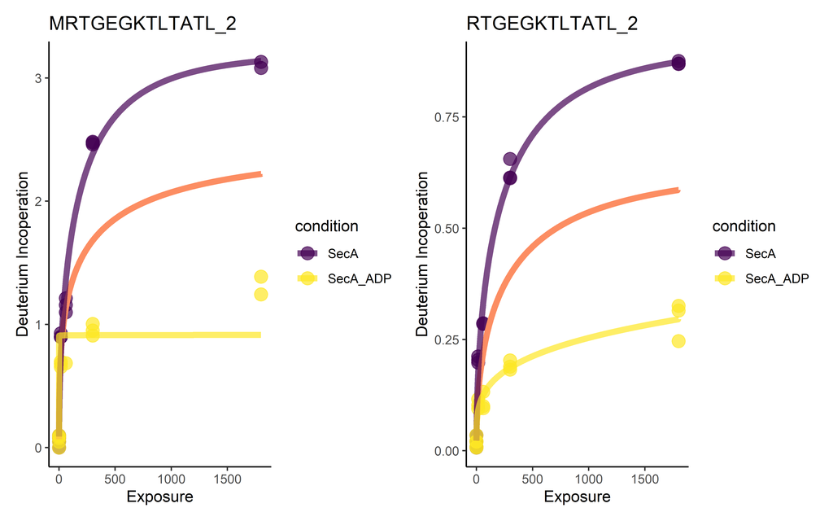

```r
res@statmodels[[24]]@vis + res@statmodels[[25]]@vis
```

We an use a forest plot to examine the differneces

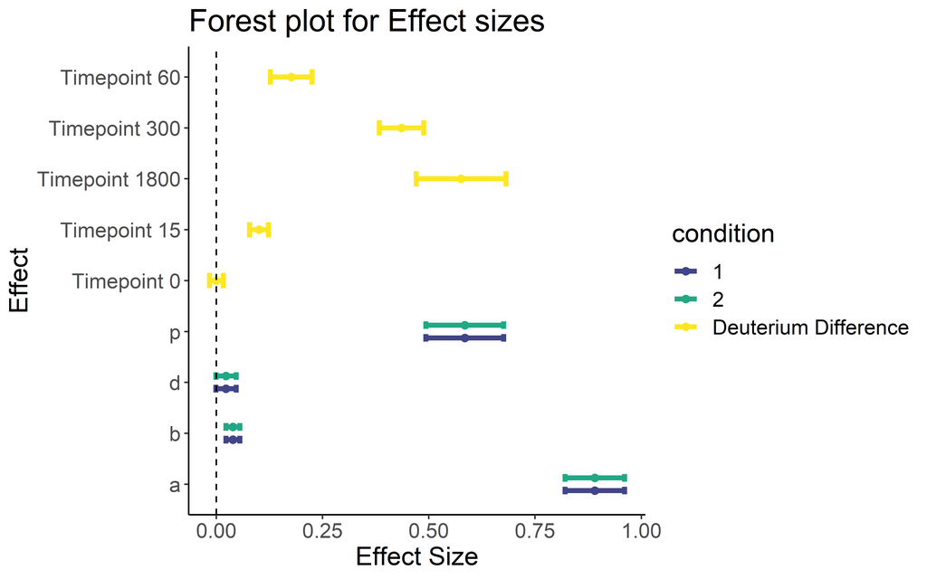

```r
fp <- forestPlot(params = res@statmodels[[25]], condition = c(1, 2))
```

```r
knitr::kable(fp$data)
```

|  | Estimate | confL | confU | rownames | condition |
| --- | --- | --- | --- | --- | --- |
| a | 0.8908128 | 0.8208193 | 0.9608062 | a | 1 |
| d | 0.0227637 | -0.0011466 | 0.0466741 | d | 1 |
| p | 0.5846715 | 0.4930051 | 0.6763380 | p | 1 |
| b | 0.0389411 | 0.0227561 | 0.0551262 | b | 1 |
| a1 | 0.8908128 | 0.8208193 | 0.9608062 | a | 2 |
| d1 | 0.0227637 | -0.0011466 | 0.0466741 | d | 2 |
| p1 | 0.5846715 | 0.4930051 | 0.6763380 | p | 2 |
| b1 | 0.0389411 | 0.0227561 | 0.0551262 | b | 2 |
| 1 | 0.0000000 | -0.0162251 | 0.0162251 | Timepoint 0 | Deuterium Difference |
| 2 | 0.1003596 | 0.0779054 | 0.1228137 | Timepoint 15 | Deuterium Difference |
| 3 | 0.1761736 | 0.1270021 | 0.2253451 | Timepoint 60 | Deuterium Difference |
| 4 | 0.4358939 | 0.3836491 | 0.4881387 | Timepoint 300 | Deuterium Difference |
| 5 | 0.5759391 | 0.4704157 | 0.6814625 | Timepoint 1800 | Deuterium Difference |